# Cx4073 : Assignment 2

Chiripal Vansh Jaiprakash

U1622893A

### Targeted Marketing for Car Insurance

Suppose you the Data Scientist in a small Car Insurance company, and you want to judge if the Customers will accept or reject a new Insurance product that the company is going to launch. Your company did a pilot with 9000 customers and obtained the corresponding dataset. The classification goal is to learn from this pilot, and predict if a targeted customer will respond *Yes* to the offer. Your company also wants to identify the top three variables that may affect the response of the customers, and they also want to know how to increase the chances for the customers to respond *Yes* to the offered Insurance product.

### Analysis of Marketing Data

Import the CSV data file `assign2_MarketData.csv` for analysis, and quickly check the structure of the data.

```r
install.packages("DMwR", repos = "https://cran.asia/")
install.packages("tree", repos = "https://cran.asia/")
install.packages("rpart", repos = "https://cran.asia/")
```

```r
install.packages("rpart.plot", repos = "https://cran.asia/")
install.packages("randomForest", repos = "https://cran.asia/")
install.packages("Boruta", repos = "https://cran.asia/")
marketData <- read.csv("assign2_MarketData.csv", header = TRUE)
str(marketData)
```

```
## 'data.frame':    9000 obs. of  24 variables:
##  $ Customer                     : Factor w/ 9000 levels "AA10041","AA11235",..: 2035 721 1645 8505 6230 1997 8610 4163 338 5607 ...
##  $ State                        : Factor w/ 5 levels "Arizona","California",..: 4 2 2 2 4 3 1 2 2 2 ...
##  $ Customer.Lifetime.Value      : num  24179 5462 4890 7433 2237 ...
##  $ Coverage                     : Factor w/ 3 levels "Basic","Extended",..: 2 1 1 1 1 1 1 2 1 1 ...
##  $ Education                    : Factor w/ 5 levels "Bachelor","College",..: 2 4 1 2 2 3 4 4 1 1 ...
##  $ Effective.To.Date            : Factor w/ 59 levels "1/1/11","1/10/11",..: 18 29 57 7 54 31 30 31 23 33 ...
##  $ EmploymentStatus             : Factor w/ 5 levels "Disabled","Employed",..: 2 2 2 2 5 1 5 2 5 5 ...
##  $ Gender                       : Factor w/ 2 levels "F","M": 2 1 1 1 1 1 2 2 1 1 ...
##  $ Income                       : int  43704 39626 46819 58839 0 25703 0 44379 0 0 ...
##  $ Location.Code                : Factor w/ 3 levels "Rural","Suburban",..: 2 2 3 1 2 2 2 2 2 2 ...
##  $ Marital.Status               : Factor w/ 3 levels "Divorced","Married",..: 2 2 1 3 2 2 3 2 3 3 ...
##  $ Monthly.Premium.Auto         : int  201 69 62 65 61 62 107 83 101 116 ...
##  $ Months.Since.Last.Claim      : int  29 23 15 4 19 4 22 10 10 12 ...
##  $ Months.Since.Policy.Inception: int  67 0 0 65 44 64 96 12 48 76 ...
##  $ Number.of.Open.Complaints    : int  0 0 0 3 0 0 0 1 0 1 ...
##  $ Number.of.Policies           : int  2 3 5 2 1 1 4 8 2 2 ...
##  $ Policy.Type                  : Factor w/ 3 levels "Corporate Auto",..: 2 2 2 2 2 2 2 3 2 2 ...
##  $ Policy                       : Factor w/ 9 levels "Corporate L1",..: 6 6 5 6 5 6 5 9 6 6 ...
##  $ Renew.Offer.Type             : Factor w/ 4 levels "Offer1","Offer2",..: 1 2 1 1 3 1 4 2 1 1 ...
##  $ Sales.Channel                : Factor w/ 4 levels "Agent","Branch",..: 2 1 1 3 1 3 4 3 1 1 ...
##  $ Total.Claim.Amount           : num  1064 486 158 19 293 ...
##  $ Vehicle.Class                : Factor w/ 6 levels "Four-Door Car",..: 3 1 1 6 1 1 5 1 5 5 ...
##  $ Vehicle.Size                 : Factor w/ 3 levels "Large","Medsize",..: 2 1 1 2 3 3 2 2 2 3 ...
##  $ Response                     : Factor w/ 2 levels "No","Yes": 1 1 1 1 1 1 1 1 1 1 ...
```

The goal is to predict the response variable `Response` for each person – that is, whether a person would accept the new *Insurance Product* being offered by your company. Before doing that, tag the variables under **Demographic Profile** or **Insurance Profile** of the customers, as per our understanding.

The variables can be listed as follows:

| Variable | Profile |
| --- | --- |
| Customer | None |
| State | Demographic |
| Customer.Lifetime.Value | Insurance |
| Coverage | Insurance |
| Education | Demographic |
| Effective.To.Date | None |
| EmploymentStatus | Demographic |
| Gender | Demographic |
| Income | Insurance |
| Location.Code | Demographic |
| Marital.Status | Demographic |
| Monthly.Premium.Auto | Insurance |
| Months.Since.Last.Claim | Insurance |
| Months.Since.Policy.Inception | Insurance |
| Number.of.Open.Complaints | Insurance |
| Number.of.Policies | Insurance |
| Policy.Type | Insurance |
| Policy | Insurance |
| Renew.Offer.Type | Insurance |
| Sales.Channel | Insurance |
| Total.Claim.Account | Insurance |
| Vehicle.Class | Demographic |
| Vehicle.Size | Demographic |

`Customer`, which appears to be like the primary key is irrelevant for our output variable. `Effective.to.Date` is also widely spread and does not hold any meaningful information. Most of the variables that have been classified as *Demographic* represent information relevant to the people and their surroundings. Culture and society can be a deteminant of most of these variables thereby being defined as Demographic. For example, the `State`, `Location.Code`, `Gender`, `Marital Status`, etc. are all personal information that do no add any definitive value to understanding the insurance aspect of any individual. Simliarly, variables that have been defined as *Insurance Policy* are the ones which involve factors that appear to be relevant while taking decisions pertaining to someone’s insurance. These involve `Income`, `Number.of.Policies`, etc.

#### Problem 1

Build an optimal tree-based classification model for `Response` vs just the **Insurance Profile** of a customer. Check the relevant accuracy parameters of your model, and use it to predict `Response` in the `assign2_MarketPred.csv`.

- Identify the *top three* important variables in this case.
- Why are they important? Justify in terms of the Pilot data.
- How would you influence `Response` using these variables?

#### Answer 1

**Exploratory Data Analaysis**

```r
insuranceMarketData <- subset(marketData, select = -c(Customer, State, Education, Effective.To.Date, EmploymentStatus, Gender, Location.Code, Marital.Status, Vehicle.Class, Vehicle.Size, Number.of.Open.Complaints))
dim(insuranceMarketData)
```

```
## [1] 9000   13
```

```r
names(insuranceMarketData)
```

```
##  [1] "Customer.Lifetime.Value"       "Coverage"
##  [3] "Income"                        "Monthly.Premium.Auto"
##  [5] "Months.Since.Last.Claim"       "Months.Since.Policy.Inception"
##  [7] "Number.of.Policies"            "Policy.Type"
##  [9] "Policy"                        "Renew.Offer.Type"
## [11] "Sales.Channel"                 "Total.Claim.Amount"
## [13] "Response"
```

```r
str(insuranceMarketData)
```

```
## 'data.frame':    9000 obs. of  13 variables:
##  $ Customer.Lifetime.Value      : num  24179 5462 4890 7433 2237 ...
##  $ Coverage                     : Factor w/ 3 levels "Basic","Extended",..: 2 1 1 1 1 1 1 2 1 1 ...
##  $ Income                       : int  43704 39626 46819 58839 0 25703 0 44379 0 0 ...
##  $ Monthly.Premium.Auto         : int  201 69 62 65 61 62 107 83 101 116 ...
##  $ Months.Since.Last.Claim      : int  29 23 15 4 19 4 22 10 10 12 ...
##  $ Months.Since.Policy.Inception: int  67 0 0 65 44 64 96 12 48 76 ...
##  $ Number.of.Policies           : int  2 3 5 2 1 1 4 8 2 2 ...
##  $ Policy.Type                  : Factor w/ 3 levels "Corporate Auto",..: 2 2 2 2 2 2 2 3 2 2 ...
##  $ Policy                       : Factor w/ 9 levels "Corporate L1",..: 6 6 5 6 5 6 5 9 6 6 ...
##  $ Renew.Offer.Type             : Factor w/ 4 levels "Offer1","Offer2",..: 1 2 1 1 3 1 4 2 1 1 ...
##  $ Sales.Channel                : Factor w/ 4 levels "Agent","Branch",..: 2 1 1 3 1 3 4 3 1 1 ...
##  $ Total.Claim.Amount           : num  1064 486 158 19 293 ...
##  $ Response                     : Factor w/ 2 levels "No","Yes": 1 1 1 1 1 1 1 1 1 1 ...
```

**Data Pre-Processing** The first step involves cleaning the data. The data consists of 9,000 rows and there are no missing values. The next step is making sure the data types are consistent for all the columns. Since there are a few values like `Number.of.Policies` which are *integer* but should be *categorical* instead.

```r
insuranceMarketData$Number.of.Policies <- as.factor(insuranceMarketData$Number.of.Policies)
```

After filtering the data and changing data type as and when necessary, we plot the `Response` variable to understand it’s distribution.

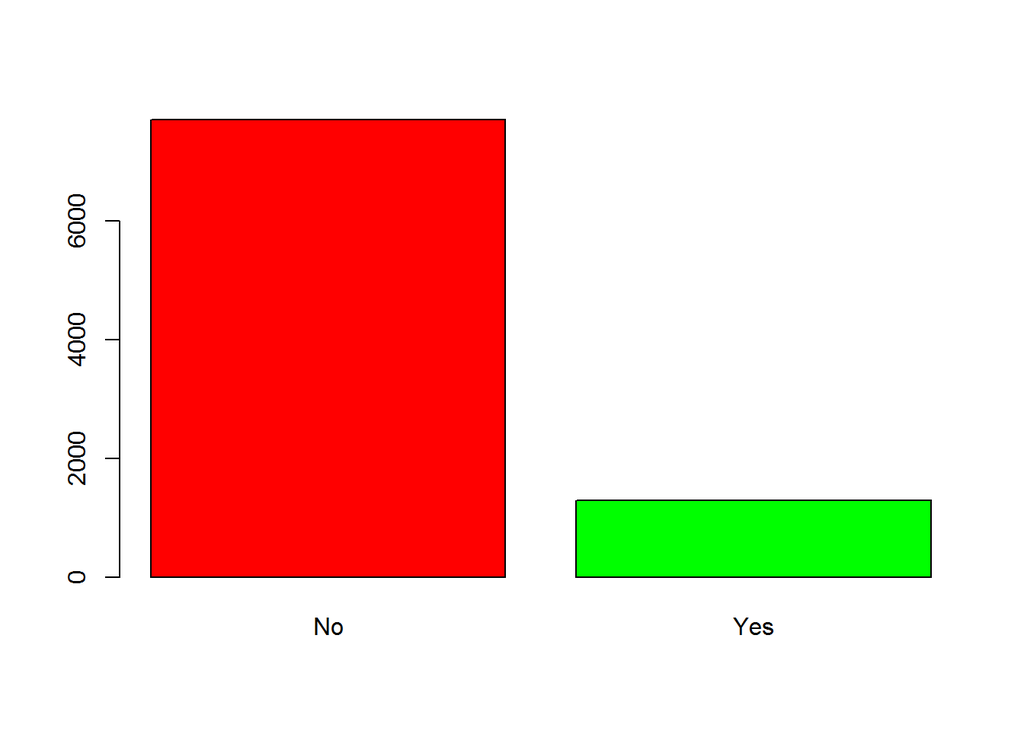

```r
cols <- c("red","green")
plot(insuranceMarketData['Response'], col=cols)
```

Observing the distribution, the data is imbalanced and it has to be balanced either using undersampling or oversampling. The most common and widely used method of oversampling is SMOTE. SMOTE stands for Synthetic Minority Oversampling TEchnique. In this, we form clusters and oversample the minority in order to minimize the imbalance in the classes available in the training data.

```r
library(DMwR)
balInsMarketData <- SMOTE(Response ~ ., data = insuranceMarketData, perc.over = 250, perc.under = 150)
summary(balInsMarketData)
```

```
##  Customer.Lifetime.Value     Coverage        Income      Monthly.Premium.Auto
##  Min.   : 1898           Basic   :4334   Min.   :    0   Min.   : 61.00
##  1st Qu.: 4372           Extended:2573   1st Qu.:16969   1st Qu.: 71.00
##  Median : 5936           Premium : 815   Median :33528   Median : 85.35
##  Mean   : 7821                           Mean   :37843   Mean   : 93.58
##  3rd Qu.: 9007                           3rd Qu.:60125   3rd Qu.:108.98
##  Max.   :74229                           Max.   :99934   Max.   :297.00
##
##  Months.Since.Last.Claim Months.Since.Policy.Inception Number.of.Policies
##  Min.   : 0.00           Min.   : 0.00                 1      :2753
##  1st Qu.: 7.00           1st Qu.:26.00                 2      :1885
##  Median :14.16           Median :49.00                 3      : 887
##  Mean   :14.97           Mean   :48.07                 9      : 505
##  3rd Qu.:22.00           3rd Qu.:68.97                 5      : 422
##  Max.   :35.00           Max.   :99.00                 7      : 353
##                                                        (Other): 917
##          Policy.Type            Policy     Renew.Offer.Type     Sales.Channel
##  Corporate Auto:2182   Personal L3 :2561   Offer1:3297      Agent      :3137
##  Personal Auto :5094   Personal L2 :1609   Offer2:3140      Branch     :2085
##  Special Auto  : 446   Corporate L3:1076   Offer3: 774      Call Center:1415
##                        Personal L1 : 956   Offer4: 511      Web        :1085
##                        Corporate L2: 679
##                        Corporate L1: 400
##                        (Other)     : 441
##  Total.Claim.Amount Response
##  Min.   :   0.099   No :3861
##  1st Qu.: 297.600   Yes:3861
##  Median : 399.153
##  Mean   : 430.408
##  3rd Qu.: 537.600
##  Max.   :2893.240
##
```

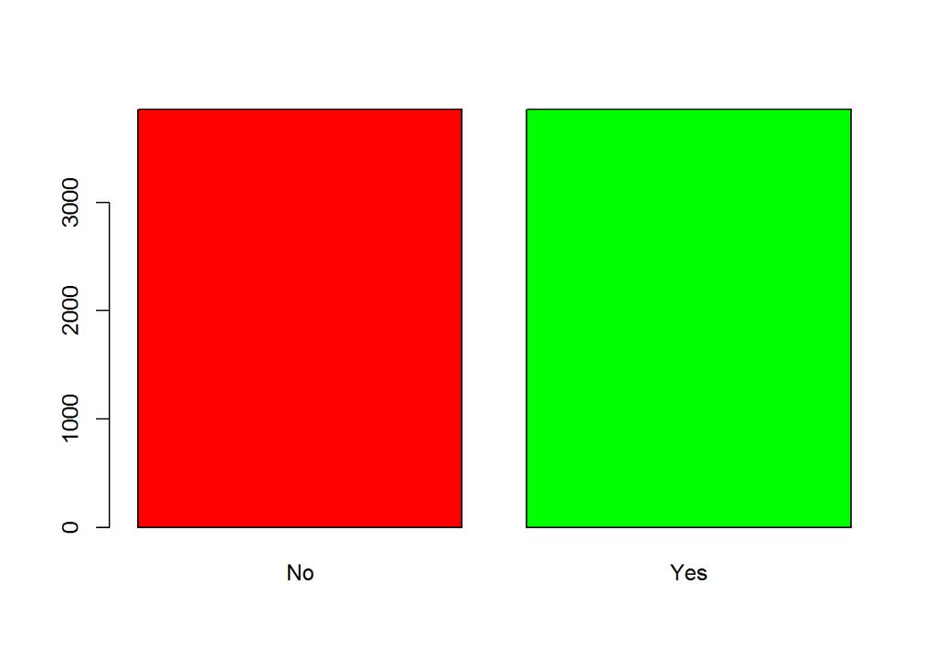

```r
cols <- c("red","green")
plot(balInsMarketData['Response'], col=cols)
```

As we can see, oversampling has helped in making the data more balanced in terms of the output classes.

**Data Analysis**

The next step involves analysing the data available to us and draw inferences. We can broadly divide the variables available to us in Categorical/Discrete and Continuous variables. Representing them through the following graphs, we observe:

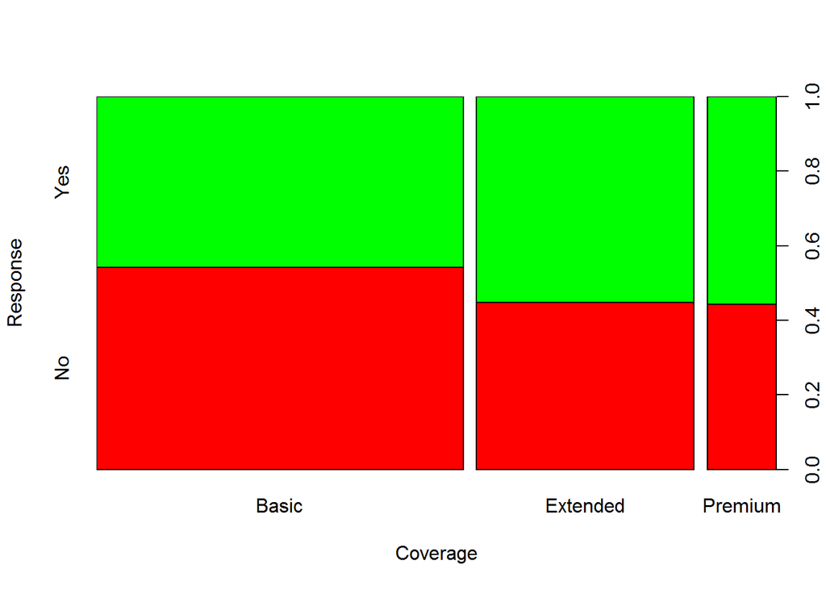

```r
# Performing analysis for categorical data

plot(balInsMarketData$Coverage, balInsMarketData$Response,
     xlab="Coverage", ylab="Response", col=cols)
```

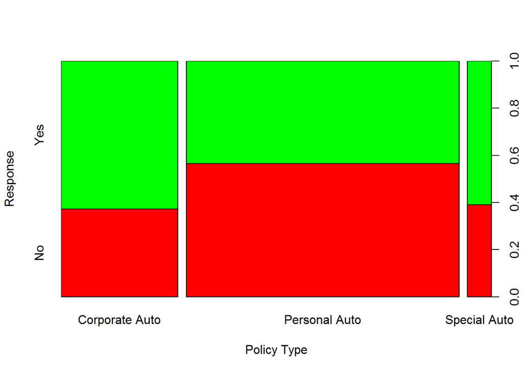

```r
plot(balInsMarketData$Policy.Type, balInsMarketData$Response,
     xlab="Policy Type", ylab="Response", col=cols)
```

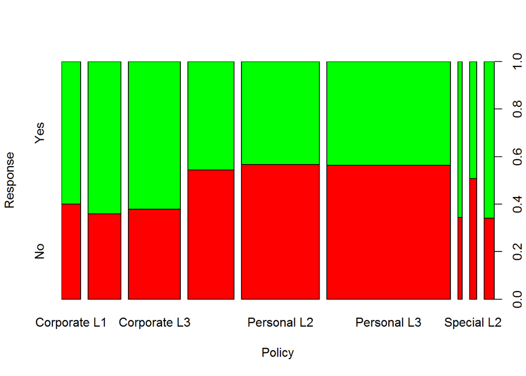

```r
plot(balInsMarketData$Policy, balInsMarketData$Response,
     xlab="Policy", ylab="Response", col=cols)
```

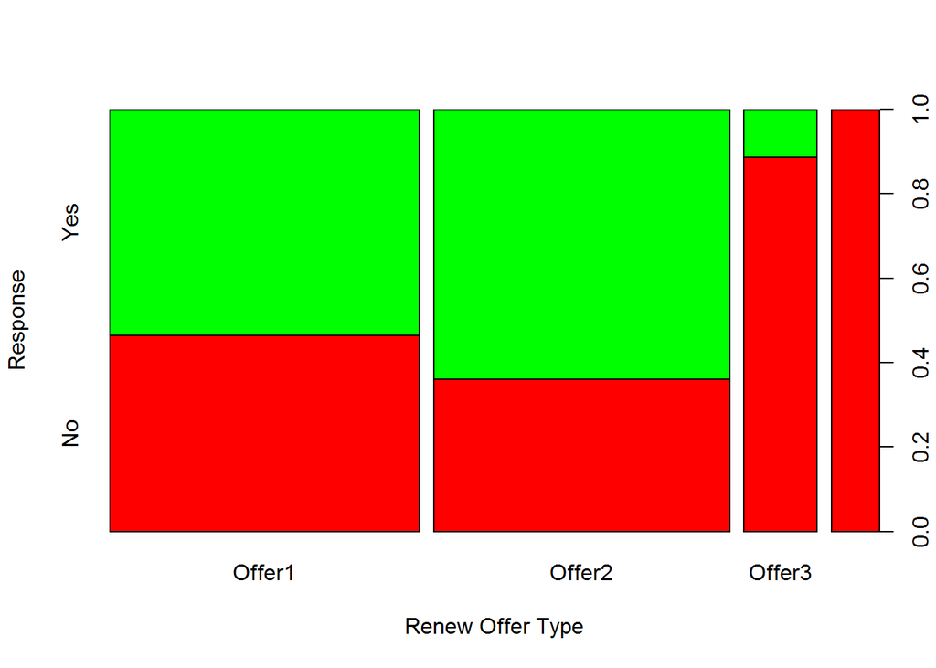

```r
plot(balInsMarketData$Renew.Offer.Type, balInsMarketData$Response,
     xlab="Renew Offer Type", ylab="Response", col=cols)
```

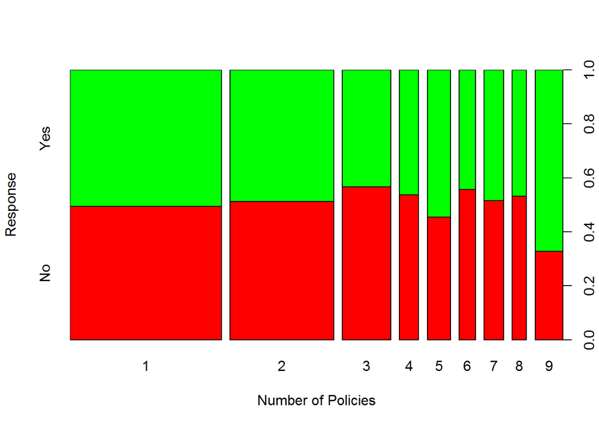

```r
plot(balInsMarketData$Number.of.Policies, balInsMarketData$Response,
     xlab="Number of Policies", ylab="Response", col=cols)
```

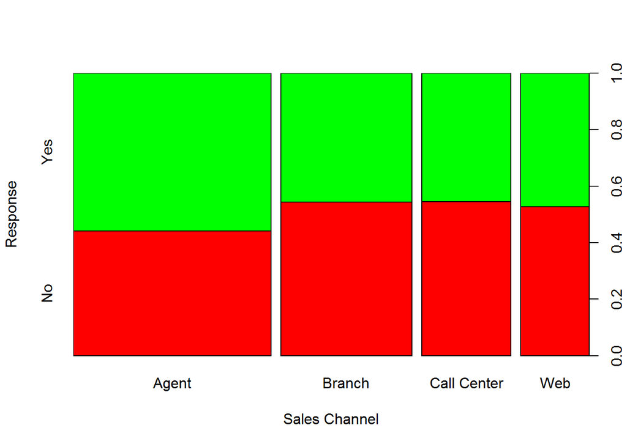

```r
plot(balInsMarketData$Sales.Channel, balInsMarketData$Response,
     xlab="Sales Channel", ylab="Response", col=cols)
```

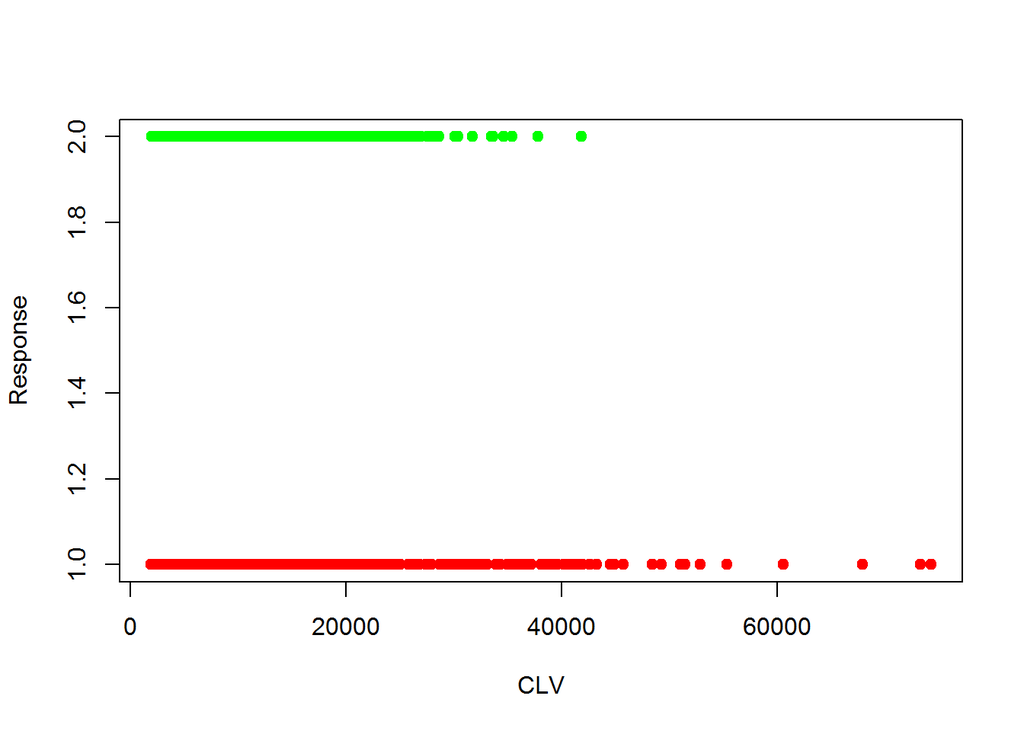

```r
# Performing analysis for continuous data

plot(balInsMarketData$Customer.Lifetime.Value, balInsMarketData$Response, xlab="CLV",
     ylab="Response", pch = 19, col = cols[(balInsMarketData$Response)])
```

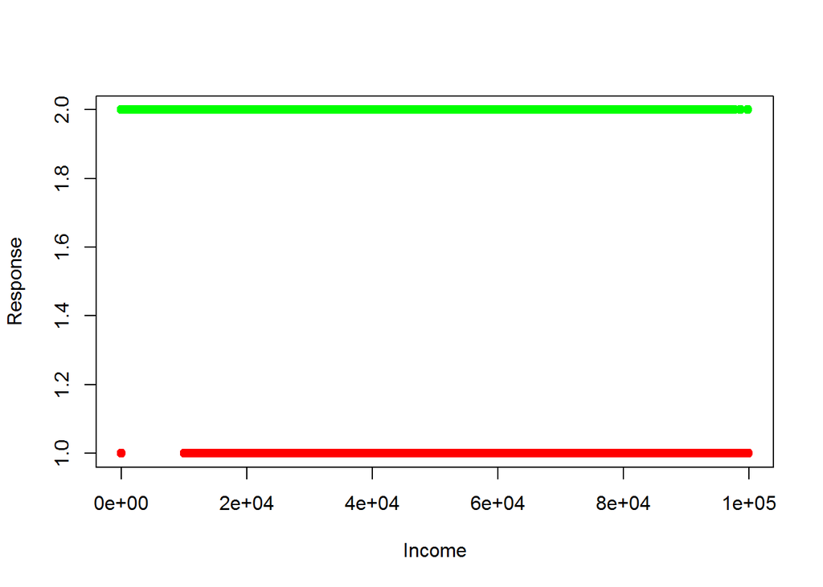

```r
plot(balInsMarketData$Income, balInsMarketData$Response, xlab="Income",
     ylab="Response", pch = 19, col = cols[(balInsMarketData$Response)])
```

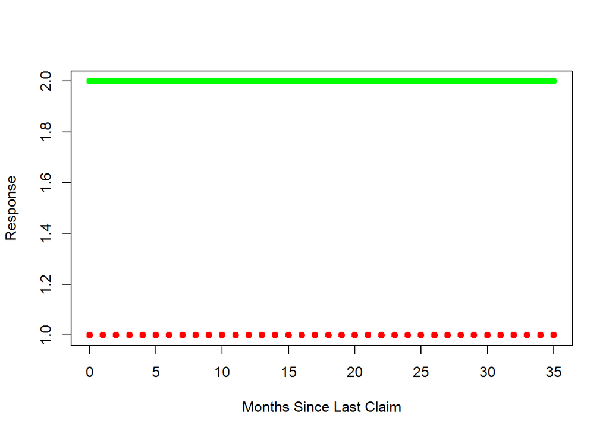

```r
plot(balInsMarketData$Months.Since.Last.Claim, balInsMarketData$Response, xlab="Months Since Last Claim",
     ylab="Response", pch = 19, col = cols[(balInsMarketData$Response)])
```

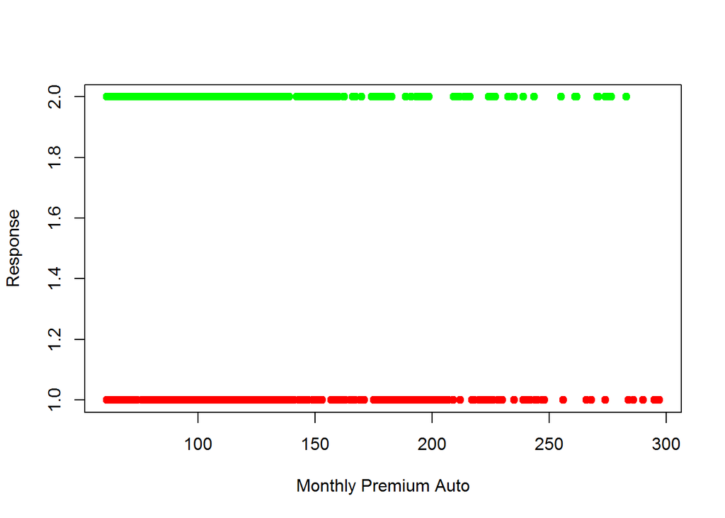

```r
plot(balInsMarketData$Monthly.Premium.Auto, balInsMarketData$Response, xlab="Monthly Premium Auto",
     ylab="Response", pch = 19, col = cols[(balInsMarketData$Response)])
```

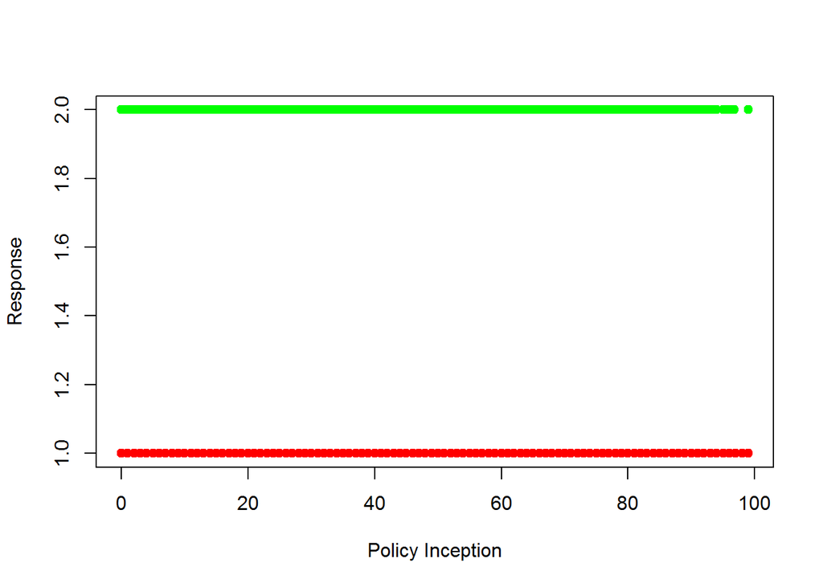

```r
plot(balInsMarketData$Months.Since.Policy.Inception, balInsMarketData$Response, xlab="Policy Inception",
     ylab="Response", pch = 19, col = cols[(balInsMarketData$Response)])
```

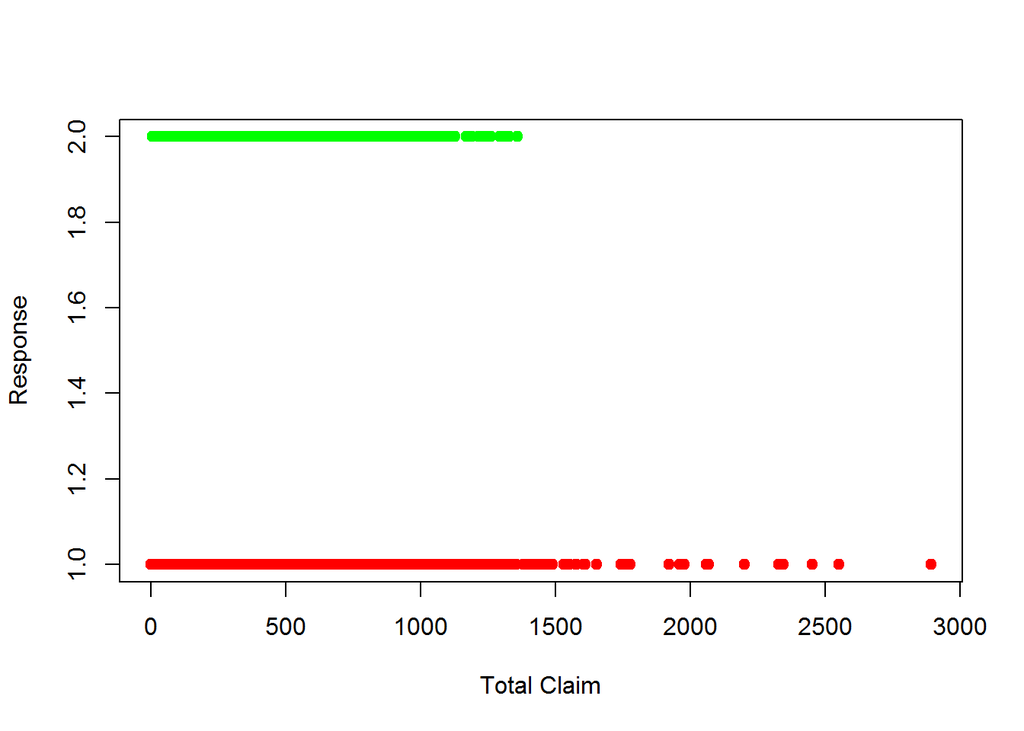

```r
plot(balInsMarketData$Total.Claim.Amount, balInsMarketData$Response, xlab="Total Claim",
     ylab="Response", pch = 19, col = cols[(balInsMarketData$Response)])
```

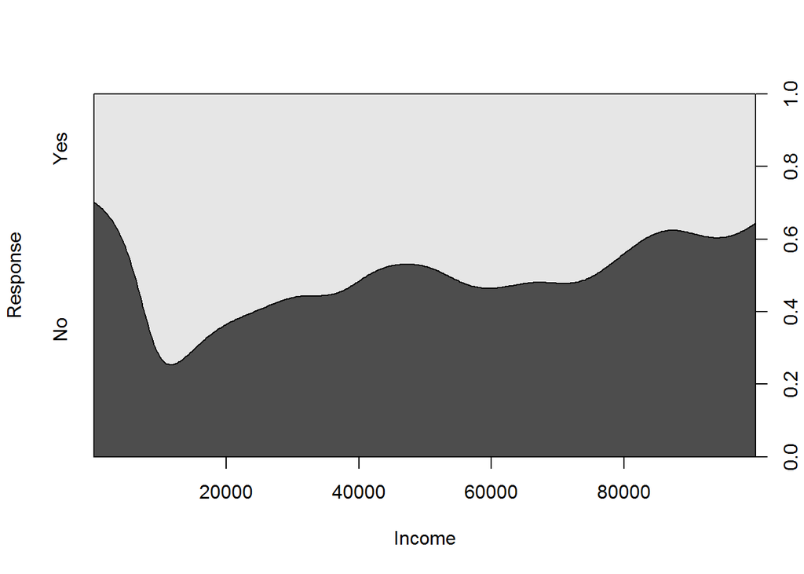

```r
# second

cdplot(balInsMarketData$Income, balInsMarketData$Response, xlab="Income",
     ylab="Response")
```

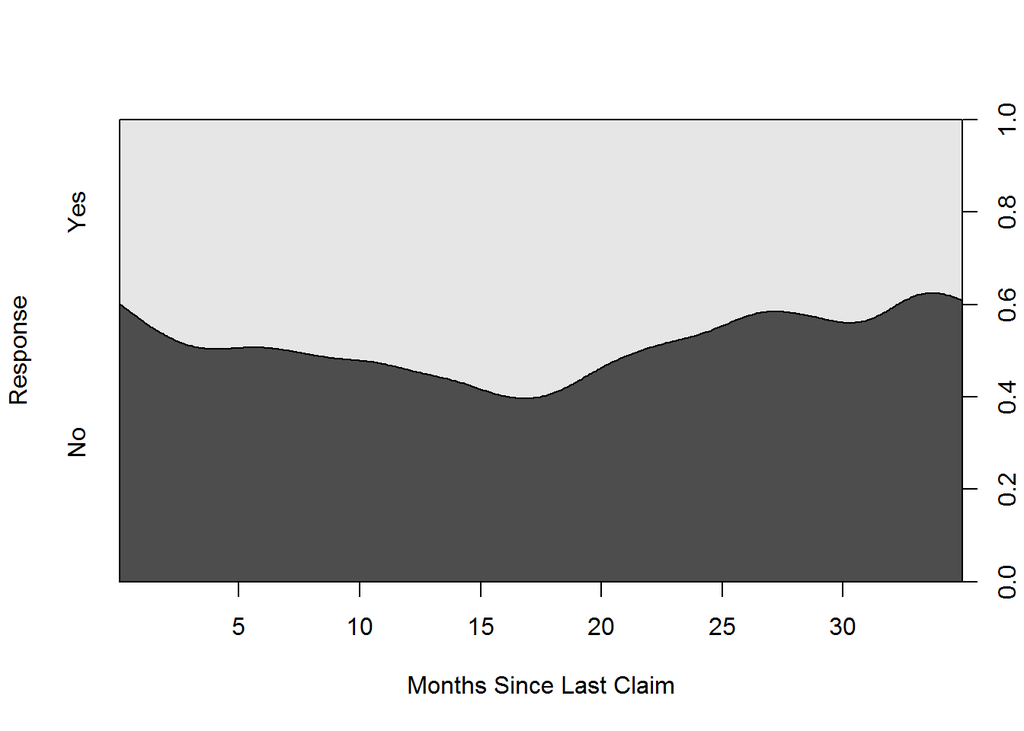

```r
cdplot(balInsMarketData$Months.Since.Last.Claim, balInsMarketData$Response, xlab="Months Since Last Claim",
     ylab="Response")
```

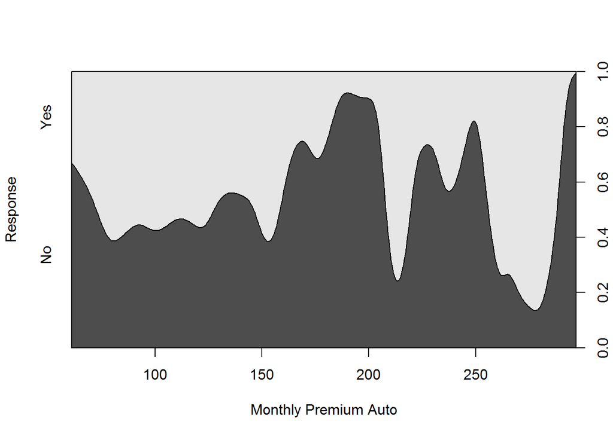

```r
cdplot(balInsMarketData$Monthly.Premium.Auto, balInsMarketData$Response, xlab="Monthly Premium Auto",
     ylab="Response")
```

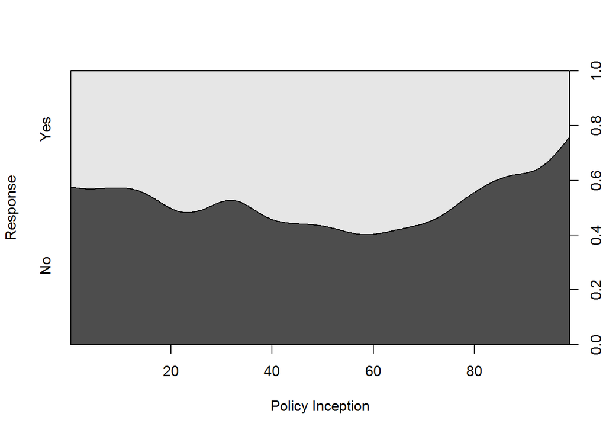

```r
cdplot(balInsMarketData$Months.Since.Policy.Inception, balInsMarketData$Response, xlab="Policy Inception",
     ylab="Response")
```

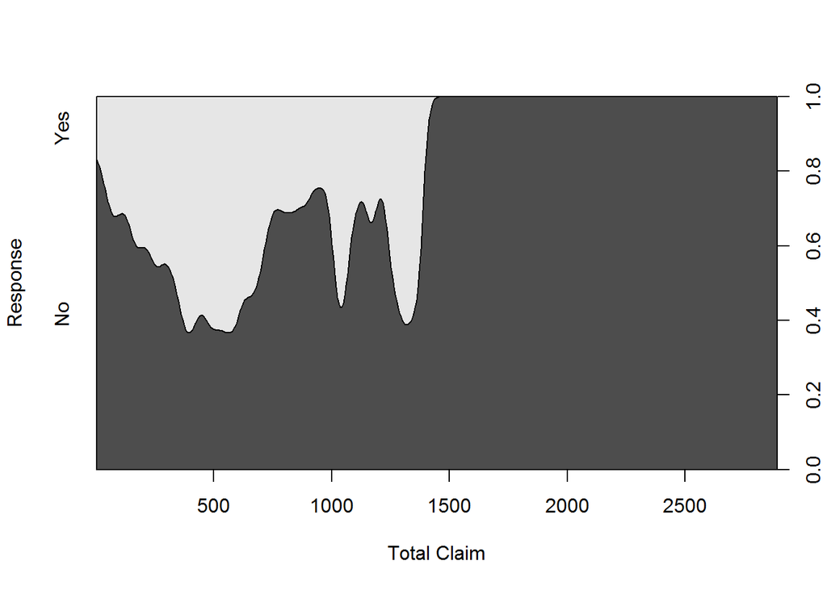

```r
cdplot(balInsMarketData$Total.Claim.Amount, balInsMarketData$Response, xlab="Total Claim",
     ylab="Response")
```

For `Customer Lifetime Value`, people with higher value seem to be more inclined towards responding No. `Income` shows people ranging from income 1,500 to 3,500 are inclined towards responding positively. Months since Last Claim and Monthly Premium Auto seems to have a random normal distribution and it is difficult to arrive at any certain conclusion. `Policy Inception` is balanced as well and high `Total Claim` is not positive for our purpose.

**Model Building**

The first step is to split the data into train and test data. We will be splitting it 70:30.

```r
train <- sample(nrow(balInsMarketData), 0.7*nrow(balInsMarketData), replace = FALSE)
balInsMarketDataTrain <- balInsMarketData[train,]
balInsMarketDataTest <- balInsMarketData[-train,]
```

The first model we will be building will be decision tree model which we will build using *rpart* library in R.

```r
library(rpart)
library(rpart.plot)
treeFitModel <- rpart(Response ~ ., data = balInsMarketDataTrain, method = 'class', control = rpart.control(cp=0))
PredBase <- predict(treeFitModel, balInsMarketDataTrain, type = 'class')
accuracyBase <- mean(PredBase == balInsMarketDataTest$Response)
accuracyBase
```

```
## [1] 0.5023127
```

```r
printcp(treeFitModel)
```

```
##
## Classification tree:
## rpart(formula = Response ~ ., data = balInsMarketDataTrain, method = "class",
##     control = rpart.control(cp = 0))
##
## Variables actually used in tree construction:
##  [1] Coverage                      Customer.Lifetime.Value
##  [3] Income                        Monthly.Premium.Auto
##  [5] Months.Since.Last.Claim       Months.Since.Policy.Inception
##  [7] Number.of.Policies            Policy
##  [9] Policy.Type                   Renew.Offer.Type
## [11] Sales.Channel                 Total.Claim.Amount
##
## Root node error: 2697/5405 = 0.49898
##
```

[output cut: 38 more lines]

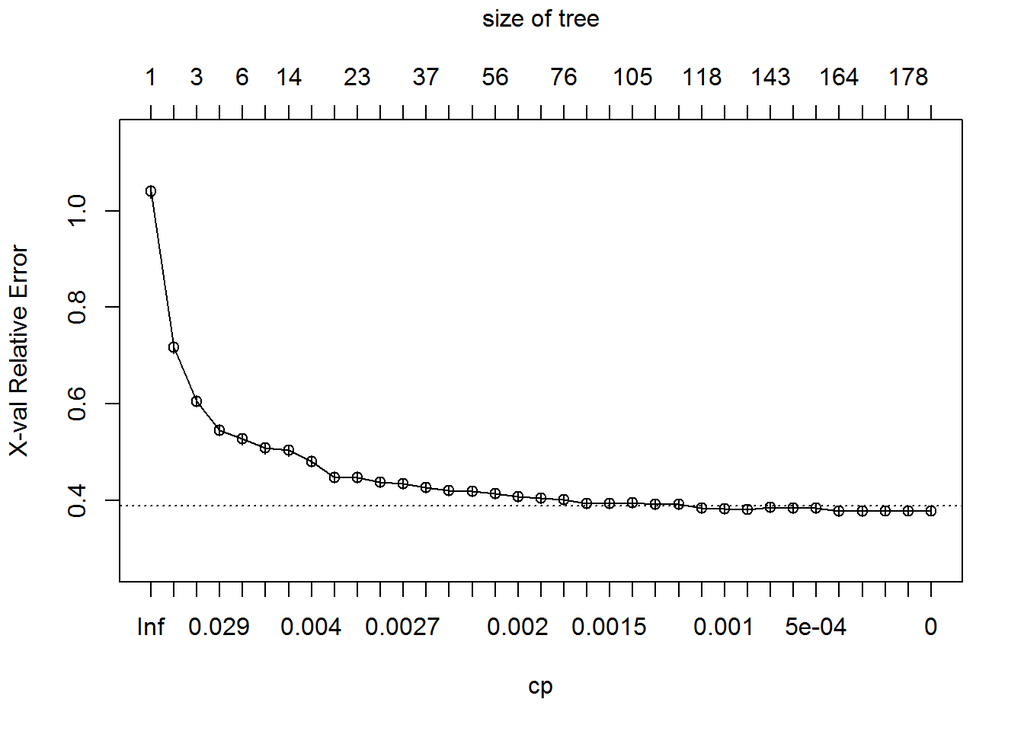

```r
plotcp(treeFitModel)
```

The printcp() and plotcp() functions help in understanding the pruning of the tree to enhance performance and improve optimality. There are two ways in which pruning can be performed, either by pre pruning, where we change the min split, min bucket etc. while making the decision tree. Minimum value of *xerror* helps in finding optimal value of CP.

*Pre-Pruning*

```r
treeFitPrePrunedModel <- rpart(Response ~ ., data = balInsMarketDataTrain, method = 'class', control = rpart.control(cp=0, maxdepth = 12,minsplit = 100))
PredBasePrePruned <- predict(treeFitPrePrunedModel, balInsMarketDataTest, type = 'class')
accuracyPrePruned <- mean(PredBasePrePruned == balInsMarketDataTest$Response)
accuracyPrePruned
```

```
## [1] 0.7643505
```

*Post-Pruning*

This helps in pruning the tree after it is completely unfolded. We can do this by defining the value of CP obtained in the base model.

```r
treeFitPostPrunedModel <- prune(treeFitModel, cp = 0.00092)
PredBasePostPruned <- predict(treeFitPostPrunedModel, balInsMarketDataTest, type = 'class')
accuracyPostPruned <- mean(PredBasePostPruned == balInsMarketDataTest$Response)
accuracyPostPruned
```

```
## [1] 0.8208891
```

*Random Forest Classification*

Random forest classification can also be used in order to attempt to enhance performance by using either GINI or deviance or Miscalssfication error as the loss function. We use the library `randomForest` to perform model building and understand the importance of variables.

```r
library("randomForest")
rfFit <- randomForest(Response ~ .,
                      data = balInsMarketDataTrain,
                      ntree = 1000,
                      mtry = 4,
                      importance = TRUE)

rfFit
```

```
##
## Call:
##  randomForest(formula = Response ~ ., data = balInsMarketDataTrain,      ntree = 1000, mtry = 4, importance = TRUE)
##                Type of random forest: classification
##                      Number of trees: 1000
## No. of variables tried at each split: 4
##
##         OOB estimate of  error rate: 6.38%
## Confusion matrix:
##       No  Yes class.error
## No  2460  237  0.08787542
## Yes  108 2600  0.03988183
```

```r
predRF <- predict(rfFit, balInsMarketDataTest, type="class")
mean(predRF == balInsMarketDataTest$Response)
```

```
## [1] 0.939577
```

```r
importance(rfFit)
```

```
##                                      No       Yes MeanDecreaseAccuracy
## Customer.Lifetime.Value        67.68147 101.50592            112.18459
## Coverage                       29.84022  30.44884             36.08962
## Income                         94.13564 130.02133            140.23433
## Monthly.Premium.Auto           43.66035  98.83394             83.12343
## Months.Since.Last.Claim        51.98369 107.80670            108.23281
## Months.Since.Policy.Inception  52.83223 107.22631            110.10682
## Number.of.Policies             62.49074  96.92542            103.60384
## Policy.Type                    55.69387 -26.29904             55.65279
## Policy                         59.45897 -18.11625             60.72997
## Renew.Offer.Type              136.81848 171.47272            190.96239
## Sales.Channel                  42.17200  89.29312             88.91531
## Total.Claim.Amount             70.81216 124.73799            132.46895
##                               MeanDecreaseGini
## Customer.Lifetime.Value              272.63924
## Coverage                              57.67487
## Income                               362.62863
## Monthly.Premium.Auto                 252.86280
## Months.Since.Last.Claim              210.50908
## Months.Since.Policy.Inception        247.30050
## Number.of.Policies                   167.36979
## Policy.Type                          125.45513
## Policy                               216.59158
## Renew.Offer.Type                     384.52906
## Sales.Channel                         89.90712
## Total.Claim.Amount                   313.83918
```

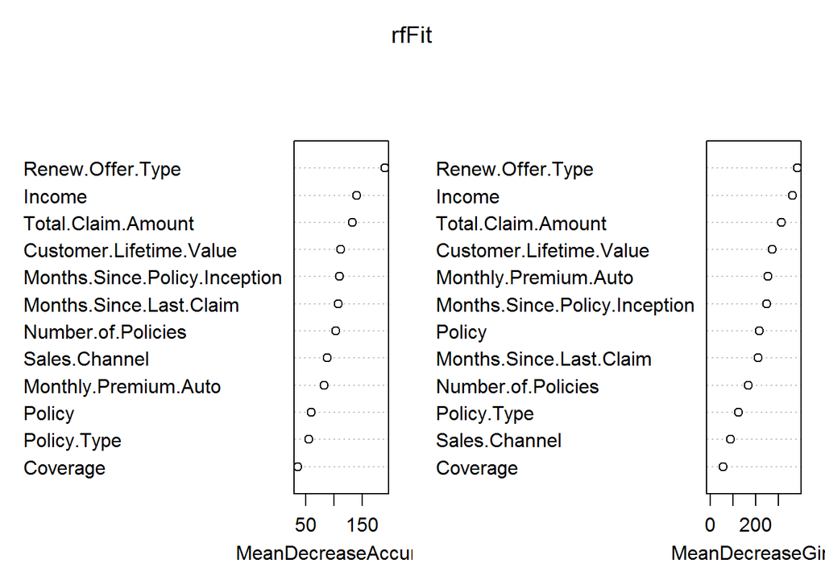

```r
varImpPlot(rfFit)
```

As we can see from the graph, the three most important variables in Insurance Policy are `Renew.Offer.Type`, `Income` and `Total.Claim.Account`. Getting rid of the last few variables can help in improving the accuracy and getting an optimal random forest tree. They can be considered important as -

*Renew offer type* is highly likely to determine if someone is willing to take up the offer. As we can see through the initial plots, certain offers are highly unlikely to be accepted while others are more likely.

*Income* also acts plays an important role as was guessed while performing the initial data analysis. People with higher incomes do not find the offer attractive enough and either the offer has to be ailroed to suit their needs or target audience should be reevaluated.

*Total claim account* probably plays such a huge role as in the initial graph as high claim amounts do not attract people as much.

Hence, as discussed in the above section, modifications should be made to the target audience and the methodology of offers in order to get more positive responses.

Now, as the final step, we perform prediction using random forest classification and save it.

**Prediction**

```r
marketPred <- read.csv("assign2_MarketPred.csv", header = TRUE)
marketPredFiltered = subset(marketPred, select = -c(Customer, State, Education, Effective.To.Date, EmploymentStatus, Gender, Location.Code, Marital.Status, Vehicle.Class, Vehicle.Size, Number.of.Open.Complaints))
marketPredFiltered$Number.of.Policies <- as.factor(marketPredFiltered$Number.of.Policies)
marketPredFiltered$Monthly.Premium.Auto <- as.numeric(marketPredFiltered$Monthly.Premium.Auto)
marketPredFiltered$Income <- as.numeric(marketPredFiltered$Income)
marketPredFiltered$Months.Since.Last.Claim <- as.numeric(marketPredFiltered$Months.Since.Last.Claim)
marketPredFiltered$Months.Since.Policy.Inception <- as.numeric(marketPredFiltered$Months.Since.Policy.Inception)

levels(marketPredFiltered$Policy) <- levels(marketData$Policy)

str(marketPredFiltered)
```

```
## 'data.frame':    100 obs. of  12 variables:
##  $ Customer.Lifetime.Value      : num  4737 3934 14642 3589 5839 ...
##  $ Coverage                     : Factor w/ 3 levels "Basic","Extended",..: 1 1 2 2 1 1 2 1 1 2 ...
##  $ Income                       : num  0 25927 0 42836 81082 ...
##  $ Monthly.Premium.Auto         : num  68 103 133 89 73 64 131 73 186 129 ...
##  $ Months.Since.Last.Claim      : num  2 6 24 32 5 11 12 18 0 24 ...
##  $ Months.Since.Policy.Inception: num  26 20 46 99 85 64 76 45 30 50 ...
##  $ Number.of.Policies           : Factor w/ 9 levels "1","2","3","4",..: 3 1 2 1 4 1 1 5 2 2 ...
##  $ Policy.Type                  : Factor w/ 3 levels "Corporate Auto",..: 2 2 2 1 2 1 2 2 2 2 ...
##  $ Policy                       : Factor w/ 9 levels "Corporate L1",..: 6 6 6 3 6 3 5 5 6 6 ...
##  $ Renew.Offer.Type             : Factor w/ 4 levels "Offer1","Offer2",..: 1 2 1 3 2 4 2 1 2 1 ...
##  $ Sales.Channel                : Factor w/ 4 levels "Agent","Branch",..: 2 4 1 2 1 3 3 3 2 1 ...
##  $ Total.Claim.Amount           : num  326 675 1387 245 281 ...
```

```r
str(balInsMarketDataTrain)
```

```
## 'data.frame':    5405 obs. of  13 variables:
##  $ Customer.Lifetime.Value      : num  2539 3545 6958 7019 7546 ...
##  $ Coverage                     : Factor w/ 3 levels "Basic","Extended",..: 1 2 3 1 1 1 1 1 1 2 ...
##  $ Income                       : num  18608 40658 0 26806 36383 ...
##  $ Monthly.Premium.Auto         : num  71 90 68.9 63 111.7 ...
##  $ Months.Since.Last.Claim      : num  13 25 15 32 18.7 ...
##  $ Months.Since.Policy.Inception: num  24 20 78.1 19 52.1 ...
##  $ Number.of.Policies           : Factor w/ 9 levels "1","2","3","4",..: 1 1 2 2 9 1 2 7 8 1 ...
##  $ Policy.Type                  : Factor w/ 3 levels "Corporate Auto",..: 2 2 1 2 2 2 2 2 2 2 ...
##  $ Policy                       : Factor w/ 9 levels "Corporate L1",..: 5 5 4 5 3 6 4 6 6 6 ...
##  $ Renew.Offer.Type             : Factor w/ 4 levels "Offer1","Offer2",..: 2 3 2 1 2 1 2 1 1 1 ...
##  $ Sales.Channel                : Factor w/ 4 levels "Agent","Branch",..: 4 2 1 1 1 1 2 1 1 2 ...
##  $ Total.Claim.Amount           : num  341 503 330 302 425 ...
##  $ Response                     : Factor w/ 2 levels "No","Yes": 2 1 2 2 2 2 1 2 2 2 ...
```

```r
rfP1Pred = predict(rfFit, marketPredFiltered, type="class")

rfP1PredFrame <- data.frame("Response"=rfP1Pred)
write.csv(rfP1PredFrame, "assign2_MarketPred_Insurance.csv", row.names = TRUE)
```

#### Problem 2

Build an optimal tree-based classification model for `Response` vs both **Demographic Profile** and **Insurance Profile** of a customer. Check the relevant accuracy parameters of your model, and use it to predict `Response` in the `assign2_MarketPred.csv`.

- Identify the *top three* important variables in this case.
- Why are they important? Justify in terms of the Pilot data.
- How would you influence `Response` using these variables?

#### Answer 2

**Exploratory Data Analysis**

The overall structure of this solution remains more or less similar to the previous one. There are a few other parameters that are taken into consideration (Demographic Policy).

We start off by dropping columns that do not play any role in determining the outcome of our predictions.

```r
overallMarketData <- subset(marketData, select = -c(Customer, Effective.To.Date, Number.of.Open.Complaints))
```

*Data Pre-Processing* will be performed as in Answer 1.

```r
overallMarketData$Number.of.Policies <- as.factor(overallMarketData$Number.of.Policies)
```

Understanding the distribution of `Response` will be imbalanced as in the previous part.

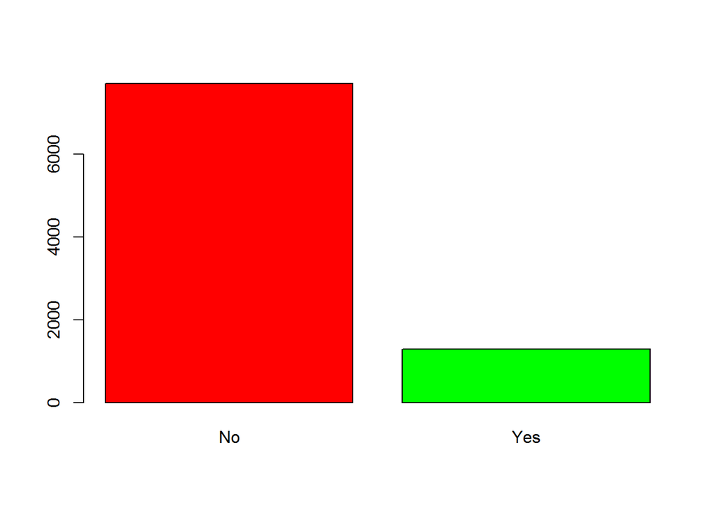

```r
cols <- c("red","green")
plot(overallMarketData['Response'], col=cols)
```

Performing Over sampling using SMOTE.

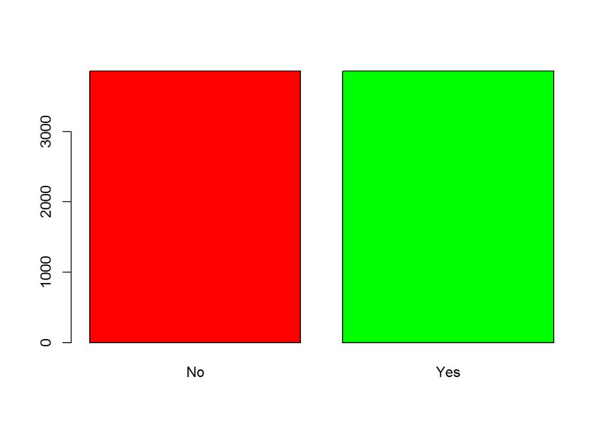

```r
balOvrMarketData <- SMOTE(Response ~ ., data = overallMarketData, perc.over = 250, perc.under = 150)
cols <- c("red","green")
plot(balOvrMarketData['Response'], col=cols)
```

*Data Analysis* The following are the plots for categorical variables.

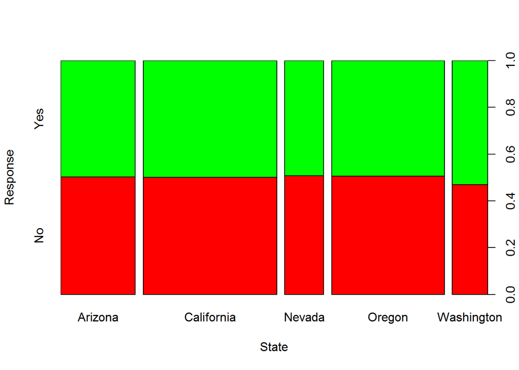

```r
plot(balOvrMarketData$State, balOvrMarketData$Response,
     xlab="State", ylab="Response", col=cols)
```

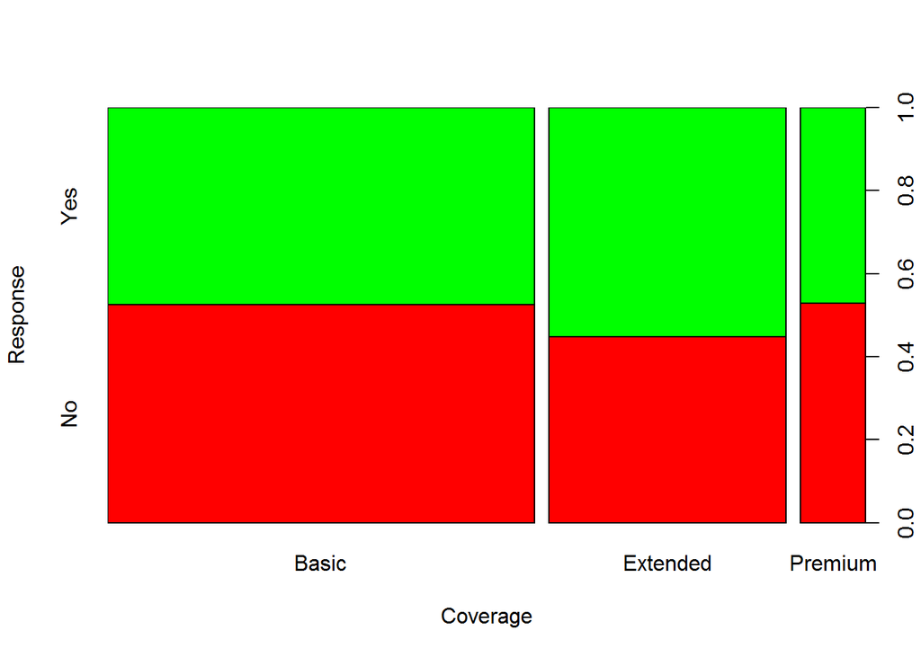

```r
plot(balOvrMarketData$Coverage, balOvrMarketData$Response,
     xlab="Coverage", ylab="Response", col=cols)
```

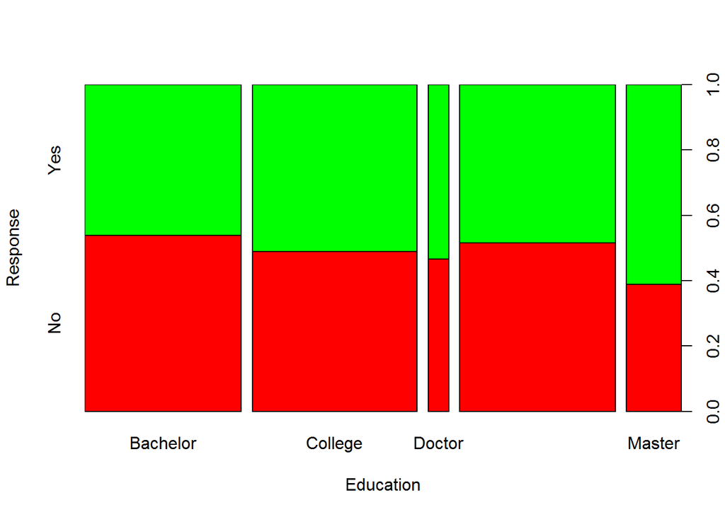

```r
plot(balOvrMarketData$Education, balOvrMarketData$Response,
     xlab="Education", ylab="Response", col=cols)
```

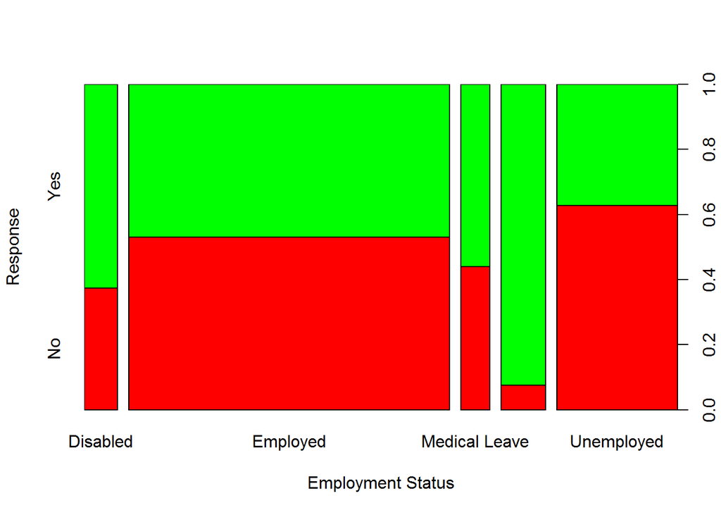

```r
plot(balOvrMarketData$EmploymentStatus, balOvrMarketData$Response,
     xlab="Employment Status", ylab="Response", col=cols)
```

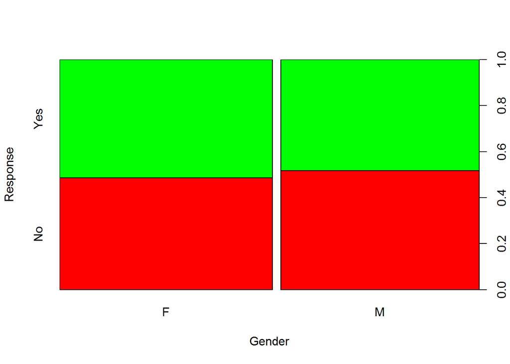

```r
plot(balOvrMarketData$Gender, balOvrMarketData$Response,
     xlab="Gender", ylab="Response", col=cols)
```

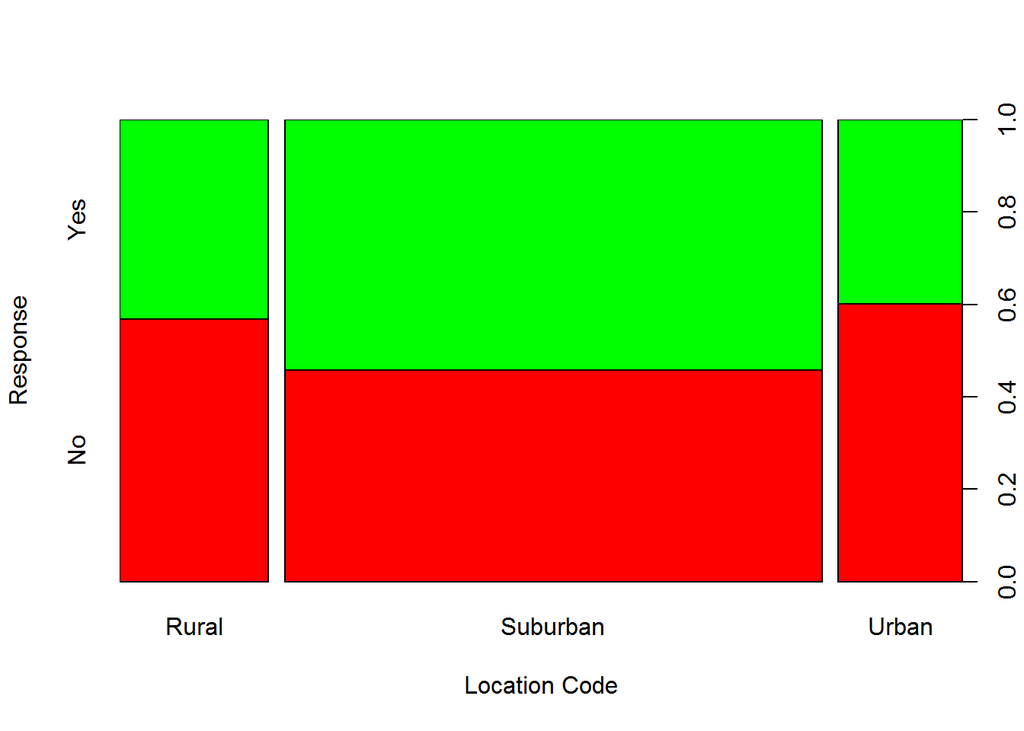

```r
plot(balOvrMarketData$Location.Code, balOvrMarketData$Response,
     xlab="Location Code", ylab="Response", col=cols)
```

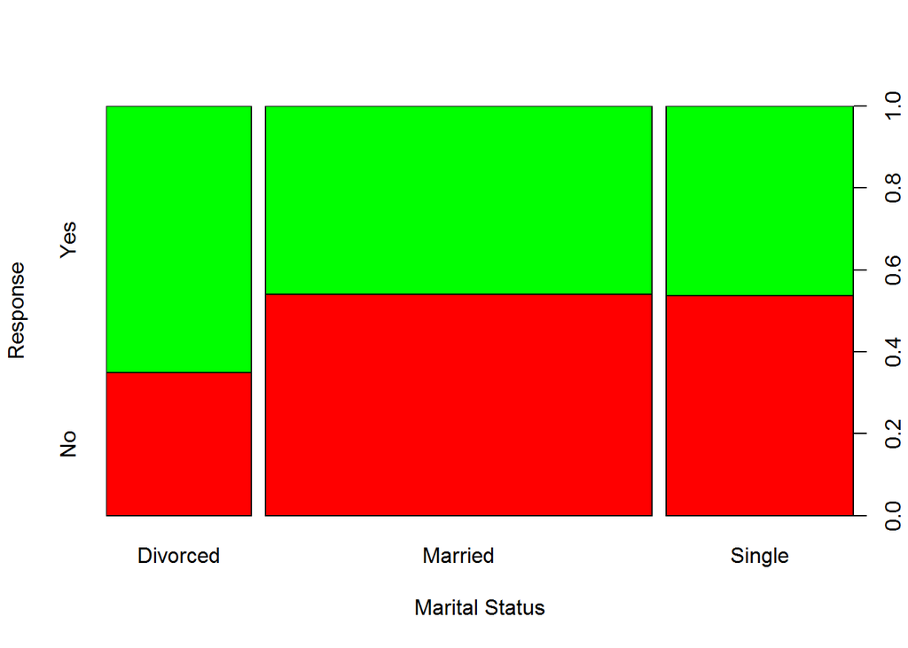

```r
plot(balOvrMarketData$Marital.Status, balOvrMarketData$Response,
     xlab="Marital Status", ylab="Response", col=cols)
```

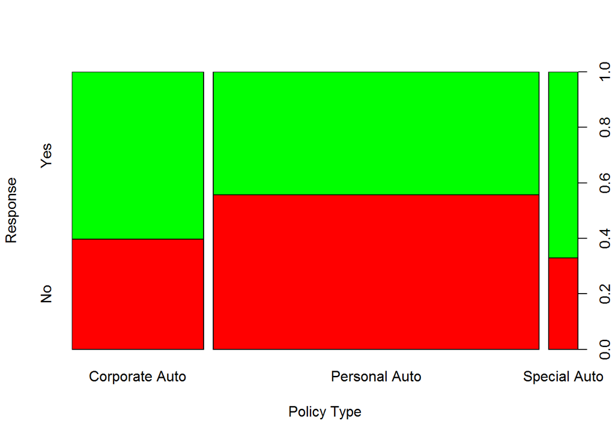

```r
plot(balOvrMarketData$Policy.Type, balOvrMarketData$Response,
     xlab="Policy Type", ylab="Response", col=cols)
```

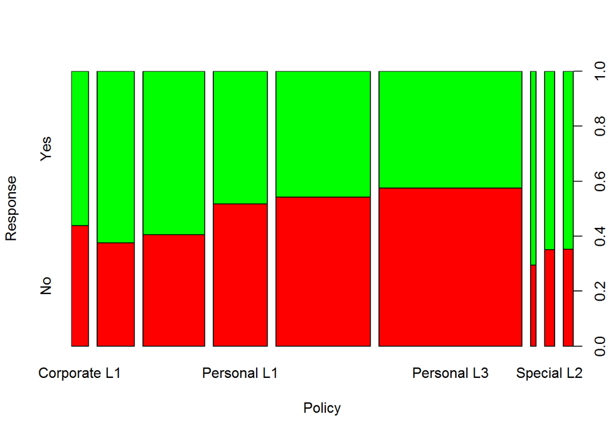

```r
plot(balOvrMarketData$Policy, balOvrMarketData$Response,
     xlab="Policy", ylab="Response", col=cols)
```